# 9. Números racionales (parte 2)

**Aclaraciones**

- Las actividades con 🔁 son de **autocorrección**.
- Primero hacelas vos, después compará con la solución al final de la guía:
  - Si está bien: marcá **✓**.
  - Si está mal: copiá la solución intentando entenderla y marcá **✓✓**.
  - Si todavía no lo entendés: preguntá en clase.
- Corregirte a vos mismo te va a ayudar a aprender más rápido y a llegar mejor preparado a las pruebas.

## La fracción como proporción

Una proporción compara dos cantidades y puedo expresarla como fracción. Observa este [fragmento de video](https://www.youtubetrimmer.com/view/?v=GF6qAfIngvo&start=0&end=53&loop=1). Verás que:

> Si hay 8 manzanas y 20 frutas la proporción de manzanas en el total de frutas es **8:20** (8 a 20) pero esto también se puede escribir como la fracción $\frac{8}{20}$ que se lee **ocho veinteavos** u **ocho sobre veinte**.

## 🔁 Actividad 1

Expresa como fracción las siguientes proporciones pedidas:

> Ejemplo: Si en un galpón hay 3 ovejas por cada 5 cerdos. ¿Cuál es la proporción de obejas respecto al total de animales? **Respuesta:** La proporción es $\frac{3}{8}$.
1. En una huerta, por cada 4 plantas de tomate hay 6 de lechuga. ¿Cuál es la proporción de lechuga respecto al total de plantas?
2. En un rodeo hay 20 vacas y 5 toros. ¿Qué fracción representan los toros respecto al total?

## Convertir una fracción a número decimal

Los números decimales son aquellos que representan valores que no son enteros, usando una coma para separar la parte entera de la parte decimal.

**Por ejemplo:**

- 3,5 → tres unidades y cinco décimas.
- 0,75 → setenta y cinco centésimas.

Para pasar una fracción a número decimal divides el numerador por el denominador. Observa como se hace en los videos ejemplos de abajo:

- [Ejemplo 1](https://www.youtube.com/watch?v=66nhcLhneIU)
- [Ejemplo 2](https://www.youtube.com/watch?v=F3VllTEYPVM)
- [Ejemplo 3](https://www.youtube.com/watch?v=MAjXxCQMgGk&list=PLFx6eqvnPSu4fuw9Cp2Gn3REC-dBsAvUM&index=29)

## 🔁 Actividad 2

Pasar estas fracciones a número decimal:

1. $\frac{7}{8}$
2. $\frac{25}{4}$
3. $\frac{5}{6}$

## Pasar de número decimal a fracción

Para pasar de número decimal a fracción debes escribir la fracción y luego simplificarla. Mira este [ejemplo](https://www.youtube.com/watch?v=YdjXZnKxudc&list=PLFx6eqvnPSu4fuw9Cp2Gn3REC-dBsAvUM&index=30).

## 🔁 Actividad 3

Pasar a fracción los siguientes números decimales:

1. 12,3
2. 0,2
3. 23,879
4. 0,01
5. 0,25

## 🔁 Actividad 4

Resuelve estos problemas que integran lo que has aprendido aquí.

1. En una jornada agrícola, un alumno trabajó $\frac{3}{5}$ del tiempo en la huerta y el resto en el invernadero. ¿Qué fracción del tiempo estuvo en el invernadero?
2. Un alumno sembró $0,25$ hectáreas con alfalfa y $\frac{1}{5}$ con maíz. ¿Con qué sembró más? Justificá.

**Soluciones para autocorregirte**

### Actividad 1

1. Respuesta: La proporción es $\frac{6}{10}$
2. Respuesta: La proporción es $\frac{5}{25}$

### Actividad 2

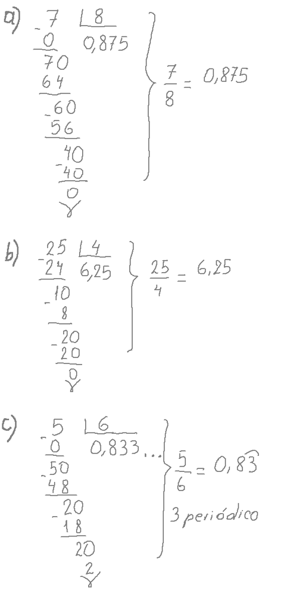

### Actividad 3

1. $12,3 = \frac{123}{10}$
2. $0,2 = \frac{2}{10} = \frac{1}{5}$
3. $23,879 = \frac{23879}{1000}$
4. $0,01 = \frac{1}{100}$
5. $0,25 = \frac{25}{100} = \frac{25 \div 25}{100 \div 25} = \frac{1}{4}$

### Actividad 4

**a.** El alumno trabajó $\frac{3}{5}$ del tiempo en la huerta y el resto en el invernadero.

- El total del tiempo es 1 (la jornada completa).
- Entonces, la fracción del tiempo en el invernadero es: $1 - \frac{3}{5} = \frac{5}{5} - \frac{3}{5} = \frac{2}{5}$
- **Respuesta:** Estuvo $\frac{2}{5}$ del tiempo en el invernadero.

**b.** El alumno sembró $0,25$ hectáreas con alfalfa y $\frac{1}{5}$ con maíz. ¿Con qué sembró más?

- Primero, pasamos $0,25$ a fracción para compararlo fácilmente: $0,25 = \frac{25}{100} = \frac{1}{4}$
- Ahora comparamos $\frac{1}{4}$ (alfalfa) con $\frac{1}{5}$ (maíz).
- Para comparar, usamos un común denominador, por ejemplo 20: $\frac{1}{4} = \frac{5}{20}, \quad \frac{1}{5} = \frac{4}{20}$
- Como $\frac{5}{20} > \frac{4}{20}$, sembró más alfalfa.
- **Respuesta:** Sembró más alfalfa porque $0,25 = \frac{1}{4}$ es mayor que $\frac{1}{5}$.